# Agricultura Irrigada do Brasil no Século XXI

25 de outubro de 2018

## Objeto

### **Avaliação da Política Nacional de Irrigação, instituída pela Lei n. 6.662/1979 e atualizada pela Lei n. 12.787/2013, no período de 2000 a 2015**

## Objetivos

- Identificar os municípios com maiores áreas irrigadas no País
- Comparar o crescimento desses municípios com o crescimento do Brasil
- Propor metodologia para análise completa da Política Nacional de Irrigação

## Justificativa

Os programas governamentais para ampliação da área irrigada no País, associados ao desenvolvimento de novas tecnologias de irrigação, impulsionaram o aumento da produção e da produtividade agrícolas, ampliando a oferta de alimentos e promovendo a estabilização da segurança alimentar. De 1974 a 2010, o Brasil passou de importador a grande exportador de alimentos. No início desse período, os gastos do trabalhador brasileiro com alimentação comprometiam 48% de sua renda, atualmente, devido ao aumento de sua renda e da baixa de preços dos produtos agrícolas, comprometem apenas 16% de sua renda para essa finalidade. **Nesse período o preço real da cesta básica caiu 50%** . Há necessidade de realizar uma avaliação completa da Política Nacional de Irrigação, visando readequar suas estratégias e seus normativos infralegais, para que o Brasil desenvolva seu potencial e nosso agronegócio possa ser competitivo nos mercados locais e internacionais.

## Método

- Importação das bases de dados Pib_Municipal IBGE e Área Irrigada dos seguintes endereços: http://www.ipeadata.gov.br/Default.aspx e https://www.ibge.gov.br/estatisticas-novoportal/economicas/contas-nacionais/9088-produto-interno-bruto-dos-municipios.html?&t=downloads
- Limpeza e tratamento dos dados no OpenRefine (127.0.0.1:3333)
- Tratamento primário dos dados das planilhas, organizando as colunas de interesse e renomeando os arquivos, antes de inserir os dados para criar os projetos no OpenRefine.
- Arquivos, tratados no OpenRefine, salvos em .xlsx, .csv e .tsv
- Arquivo "ANTONIO_areairrig1995pib.csv" disponível no GitHub: https://github.com/Antonio-Feitosa/Antonio-Feitosa_dados

## Método (Cont.)

- R > File > RMarkdown > Presentation > ioslides
- carreguei no R os pacotes: tidyverse, lubridate, janitor, readr, readxl, stringr, repmis, janitor, survey, srvyr, scales
- abri o arquivo "ANTONIO_areairrig1995pib.csv" que se encontrava no diretório "C://RFundamentos/dados_ACF/Antonio-Feitosa_dados" criando o dataset dados
- a partir de dados, criei o arquivo dadosA, colocando-o em ordem decrescente a partir da variável pib2015
- selecionei as colunas:municipio, uf, pib2000, pib2005, pib2010 e pib2015, atribuindo como dadosPIB
- Juntei as colunas municipio e uf de dadosPIB em uma coluna municipio_uf gerando o dataset e continuei a análise conforme o script deste projeto.

```
##       id    latitude longitude           municipio uf area1000ha pib2000
## 1 140010  282.384000  -606.753           Boa Vista RR          5    1223
## 2 160027   -0.804911   -52.453    Laranjal do Jari AP          9      92
## 3 170730 -113.416000  -492.716               Dueré TO         13      22
## 4 170820 -117.976000  -495.316 Formoso do Araguaia TO         29     126
## 5 171190 -107.906000  -496.199   Lagoa da Confusão TO         11      42
## 6 230760 -514.392000  -380.847   Limoeiro do Norte CE          6     113
##   pib2005 pib2010 pib2015
## 1    2265    5123    7559
## 2     184     347     560
## 3      43      56     116
## 4     178     215     357
## 5     128     170     449
## 6     270     506     816
```

```
##         id latitude longitude             municipio uf area1000ha pib2000
## 100 530010 -157.795  -479.297              Brasília DF         13   46475
## 35  330100 -217.622  -413.181 Campos dos Goytacazes RJ         26    5645
## 1   140010  282.384  -606.753             Boa Vista RR          5    1223
## 74  431440 -317.649  -523.371               Pelotas RS         14    1683
## 93  500370 -222.231   -54.812              Dourados MS          5    1023
## 77  431560 -320.349  -521.071            Rio Grande RS         13    1850
##     pib2005 pib2010 pib2015
## 100   80527  144174  215613
## 35    16653   38684   34217
## 1      2265    5123    7559
## 74     2629    4228    7390
## 93     1807    3765    7284
## 77     3015    5143    7275
```

```
##        id latitude longitude               municipio uf area1000ha pib2000
## 90 432240 -297.614  -570.853              Uruguaiana RS         93     707
## 70 431060 -291.311  -565.515                  Itaqui RS         67     294
## 82 431730  -33.525  -533.717 Santa Vitória do Palmar RS         50     178
## 84 431800 -286.578  -560.036               São Borja RS         48     332
## 97 510263 -136.587  -578.907   Campo Novo do Parecis MT         48     362
## 57 430040 -297.902  -557.949                Alegrete RS         46     407
##    pib2005 pib2010 pib2015
## 90    1651    1519    2625
## 70     486     686    1164
## 82     289     451     834
## 84     690     982    1613
## 97    1053    1026    2111
## 57     745    1064    1820
```

```
##                       municipio uf pib2000 pib2005 pib2010 pib2015
## 100                    Brasília DF   46475   80527  144174  215613
## 35        Campos dos Goytacazes RJ    5645   16653   38684   34217
## 1                     Boa Vista RR    1223    2265    5123    7559
## 74                      Pelotas RS    1683    2629    4228    7390
## 93                     Dourados MS    1023    1807    3765    7284
## 77                   Rio Grande RS    1850    3015    5143    7275
## 47              Pindamonhangaba SP    1305    2611    3856    6641
## 9                     Petrolina PE     725    1670    3434    5534
## 32                     Linhares ES     742    1402    3275    5239
## 43                   Mogi Guaçu SP    1167    1838    3593    5186
## 40                 Itapetininga SP     837    1589    2574    4126
## 19                    Barreiras BA     962    1236    1922    3716
## 25                     Araguari MG     700    1540    2148    3697
## 91                       Viamão RS     683    1330    1949    3239
```

[output cut: 86 more lines]

```
##                 municipio uf pib2000 pib2005 pib2010 pib2015
## 100              Brasília DF   46475   80527  144174  215613
## 35  Campos dos Goytacazes RJ    5645   16653   38684   34217
## 1               Boa Vista RR    1223    2265    5123    7559
## 74                Pelotas RS    1683    2629    4228    7390
## 93               Dourados MS    1023    1807    3765    7284
## 77             Rio Grande RS    1850    3015    5143    7275
```

```
##                 municipio_uf pib2000 pib2005 pib2010 pib2015
## 100              Brasília_DF   46475   80527  144174  215613
## 35  Campos dos Goytacazes_RJ    5645   16653   38684   34217
## 1               Boa Vista_RR    1223    2265    5123    7559
## 74                Pelotas_RS    1683    2629    4228    7390
## 93               Dourados_MS    1023    1807    3765    7284
## 77             Rio Grande_RS    1850    3015    5143    7275
```

## Gráfico de pontos com o ggplot2

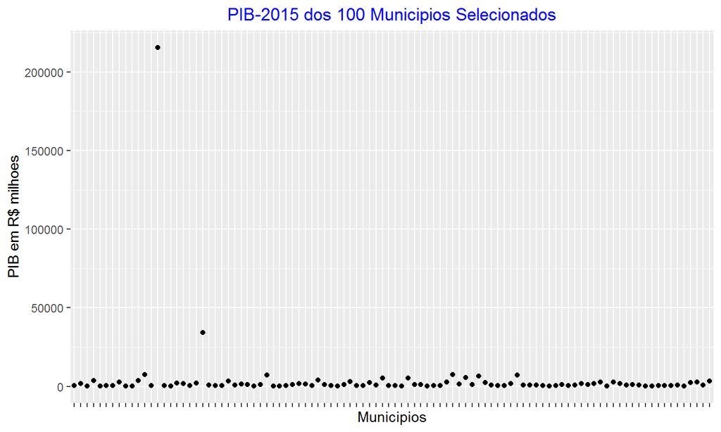

## Gráfico boxplot com R base

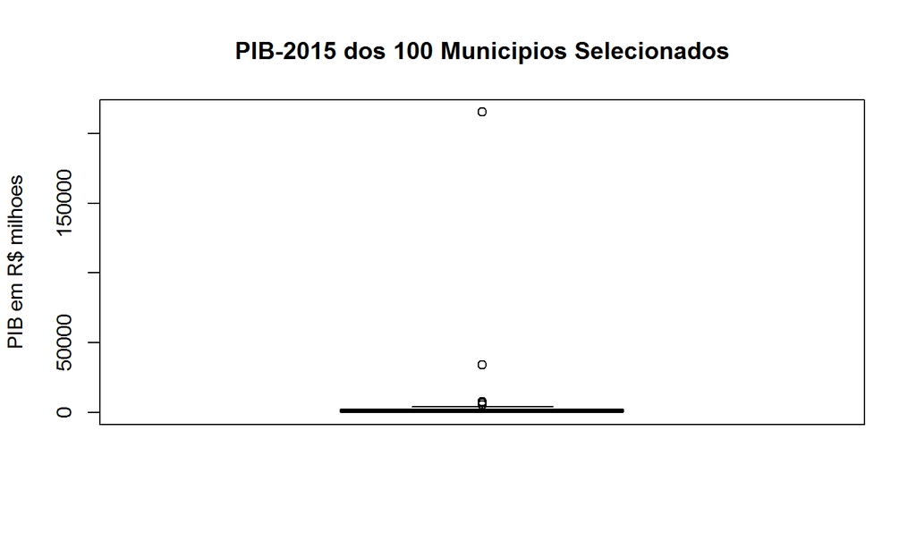

```
##          municipio_uf pib2000 pib2005 pib2010 pib2015
## 74         Pelotas_RS    1683    2629    4228    7390
## 93        Dourados_MS    1023    1807    3765    7284
## 77      Rio Grande_RS    1850    3015    5143    7275
## 47 Pindamonhangaba_SP    1305    2611    3856    6641
## 9        Petrolina_PE     725    1670    3434    5534
## 32        Linhares_ES     742    1402    3275    5239
```

```
## [1] 97
```

## Composição do PIB dos 3 outliers (%)

```
##                 outleir agropecuaria adm_publica com_ind_serv outros
## 1              Brasilia          0.3        44.7         39.9   15.1
## 2 Campos_dos_Goytacazes          0.3         5.7         94.0    0.0
## 3             Boa_Vista          7.0        48.0         37.0    8.0
```

## Gráfico de barras com as principais atividades dos outliers

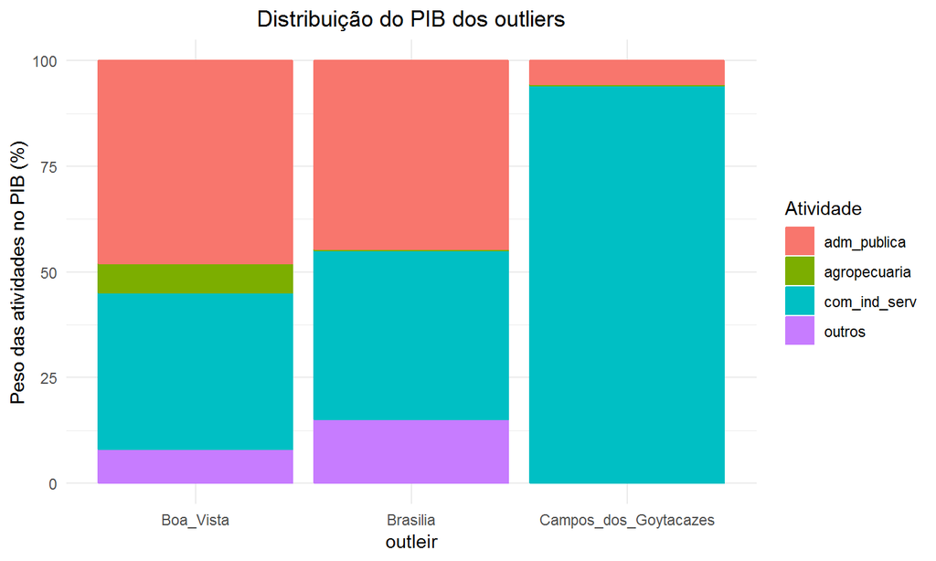

## Gráfico de pontos - PIB dos 97 municipios selecionados

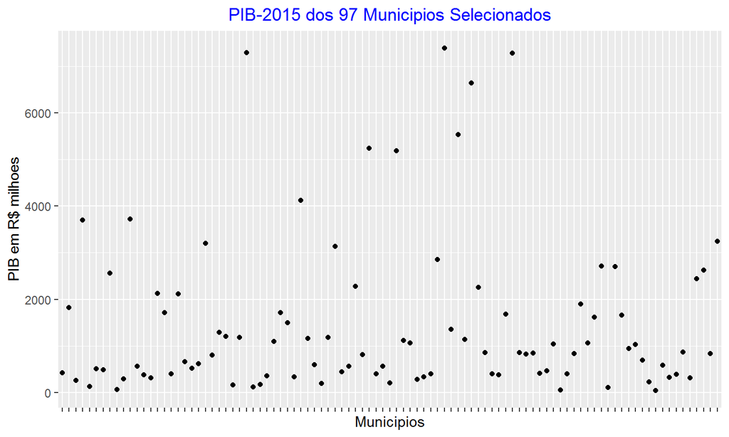

## Construindo o boxplot com o ggplot2

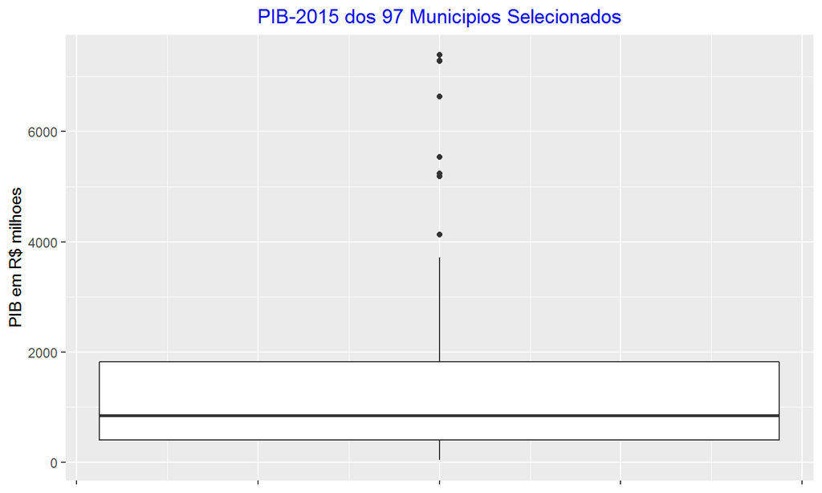

```
## [1] 3729296 4361791 6131478 6755442
```

```
## [1] 2.349528 2.372955 2.158963 2.382857
```

```
## [1] 1.014185
```

## Comparando as variações do PIB dos 97 municípios e do Brasil

```
##   Anos pibBrasil pibMunicipios
## 1 2000   3729296      87620.85
## 2 2005   4361791     103503.32
## 3 2010   6131478     132376.34
## 4 2015   6755442     160972.51
```

## Evolução do PIB dos 97 municípios entre 2000 e 2015

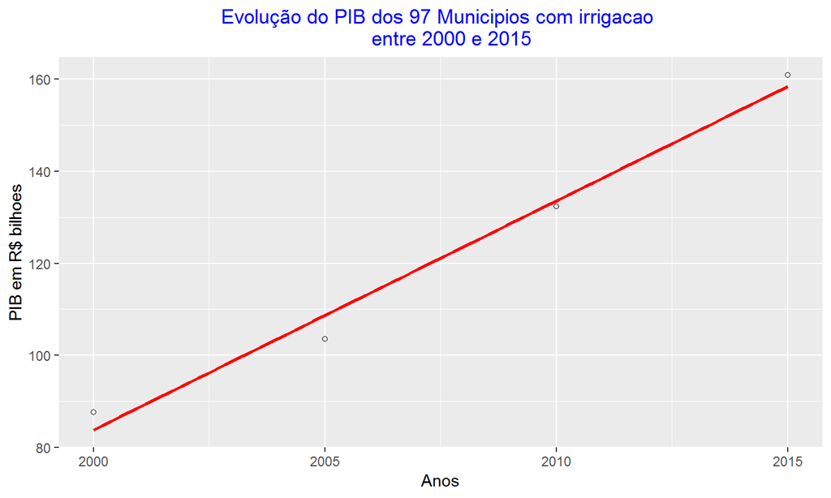

```
## [1] 83.71486
```

## Evolução do PIB brasileiro entre 2000 e 2015

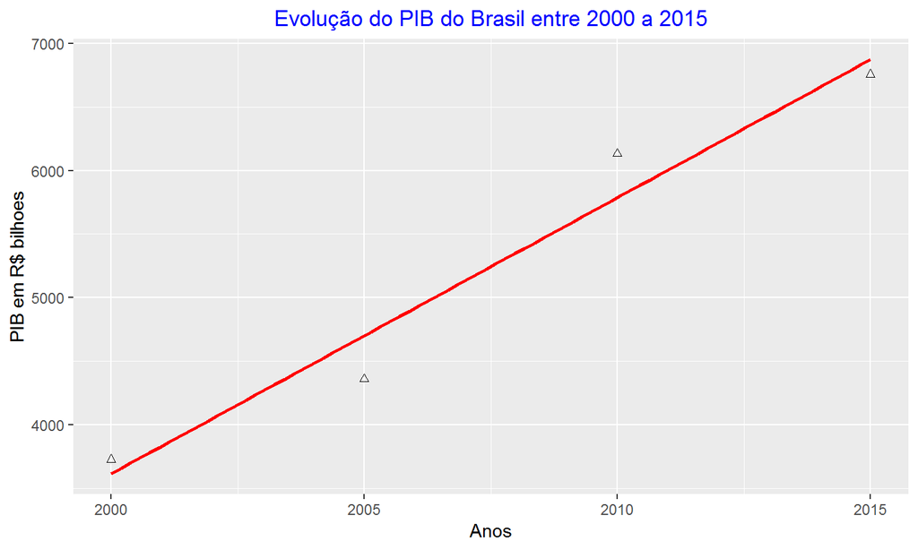

```
## [1] 81.14523
```

```
## [1] 2.56963
```

## Resultados e Discussão

Entre 2000 e 2015 o PIB dos 97 municipios selecionados (com maior área irrigada) cresceu 83,7% em termos reais((valores atualizados pelo INPC até 30/06/2018), enquanto o PIB brasileiro cresceu 81,1%. Portanto, no periodo estudado, o crescimento do PIB dos municípios com irrigação (97 selecionados) foi 2,6% maior que o crescimento do PIB brasileiro (valores absolutos).

Considerando as razões pibMunicipios/pibBrasil entre 2015 e 2000, a variacao foi de 1,4%. Isso significa que, em valores atuais (30/06/2018), apesar do elevado crescimento do PIB nacional nesse período, o crescimento do PIB dos municípios selecionados foi superior ao crescimento do PIB brasileiro (valores relativos).

## Considerações Finais

Os resultados deste **Estudo Preliminar** sinalizam que houve crescimento do PIB dos municípios que possuem agricultura irrigada maior que o crescimento do PIB brasileiro no Século XXI.

A avaliação proposta deverá ser ampliada para 40 anos, incluindo os 5.570 municipios brasileiros e outros indicadores. O roteiro deste Estudo deverá servir de base para os termos de referência visando instruir um processo para contratar uma avaliação completa da **Politica Nacional de Irrigação** no período de 1979 a 2018.